# Wstęp do programowania

Wizualizacja danych

Author

Krzysztof Dyba

# Wprowadzenie

**Wizualizacja danych** jest niezbędnym etapem w analizie danych, który pozwala odkrywać, interpretować i przedstawiać wzorce oraz trendy wynikające z danych. R oferuje wiele funkcji graficznych dzięki wbudowanemu systemowi tworzenia wykresów. Podstawową funkcją do generowania różnego rodzaju wykresów jest funkcja `plot()`, która domyślnie rysuje wykres rozrzutu (punktowy) dla dwóch zmiennych numerycznych. Niemniej, posiada ona o wiele więcej zastosowań.

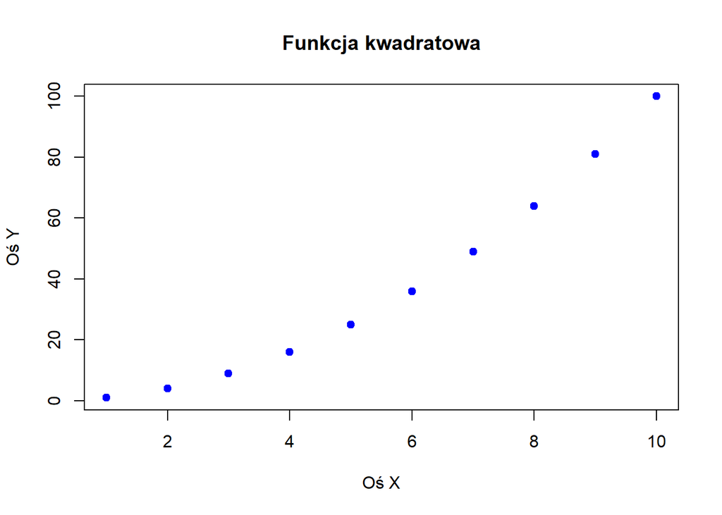

```r
x = 1:10
y = x^2

plot(x, y, main = "Funkcja kwadratowa", xlab = "Oś X", ylab = "Oś Y",
     pch = 19, col = "blue")
```

W powyższym przykładzie argumenty `x` i `y` to zmienne wejściowe (dane), `main` to tytuł wykresu, `xlab` i `ylab` to etykiety osi X i Y, `pch` to symbol punktu, a `col` to kolor punktów.

# Rodzaje wykresów

`mtcars` to jeden z wbudowanych zestawów danych w R, który zawiera informacje o 32 różnych modelach samochodów z magazynu Motor Trend US z 1974 r. Zawiera 11 zmiennych (kolumn) związanych z osiągami i konstrukcją tych samochodów. Na jego podstawie wygenerujemy cztery podstawowe typy wykresów. Dokumentację zbioru można sprawdzić używając `?mtcars`.

```r
# wczytanie danych do sesji
mtcars = mtcars

# struktura danych
str(mtcars)
```

```
'data.frame':   32 obs. of  11 variables:
 $ mpg : num  21 21 22.8 21.4 18.7 18.1 14.3 24.4 22.8 19.2 ...
 $ cyl : num  6 6 4 6 8 6 8 4 4 6 ...
 $ disp: num  160 160 108 258 360 ...
 $ hp  : num  110 110 93 110 175 105 245 62 95 123 ...
 $ drat: num  3.9 3.9 3.85 3.08 3.15 2.76 3.21 3.69 3.92 3.92 ...
 $ wt  : num  2.62 2.88 2.32 3.21 3.44 ...
 $ qsec: num  16.5 17 18.6 19.4 17 ...
 $ vs  : num  0 0 1 1 0 1 0 1 1 1 ...
 $ am  : num  1 1 1 0 0 0 0 0 0 0 ...
 $ gear: num  4 4 4 3 3 3 3 4 4 4 ...
 $ carb: num  4 4 1 1 2 1 4 2 2 4 ...
```

## Wykres rozrzutu

Wykres rozrzutu przedstawia związek między dwiema zmiennymi ciągłymi. Każdy punkt na wykresie przedstawia pojedynczą obserwację, przy czym oś X reprezentuje zmienną niezależną (wyjaśniającą), a oś Y zmienną zależną (modelowaną). Podstawowym zastosowaniem jest wizualne zbadanie potencjalnego związku (korelacji) między dwiema zmiennymi.

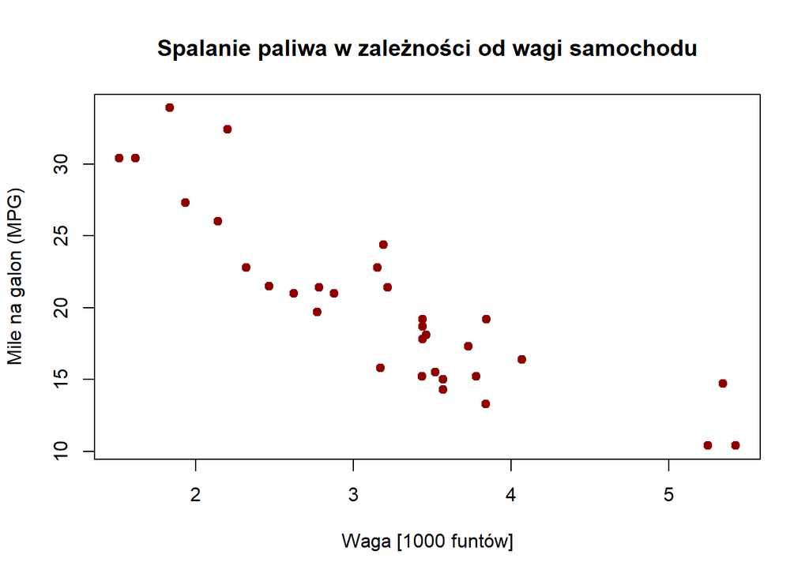

```r
plot(mtcars$wt, mtcars$mpg,
     main = "Spalanie paliwa w zależności od wagi samochodu",
     xlab = "Waga [1000 funtów]",
     ylab = "Mile na galon (MPG)",
     pch = 19,
     col = "darkred")
```

## Wykres liniowy

Wykres liniowy jest najczęściej używany do pokazywania trendów lub zmian w czasie. Oś pozioma (X) zazwyczaj reprezentuje czas, jednak nie jest to regułą. Linie proste łączą kolejne punkty, pokazując trend lub przebieg zmian, co pomaga przedstawić, w jaki sposób zmienna zależna na osi Y zmienia się wraz ze zmienną niezależną na osi X. Do utworzenia wykresu liniowego należy użyć argumentu `type` w funkcji `plot()` ustawionego na literę `"l"` (skrót od słowa *line*).

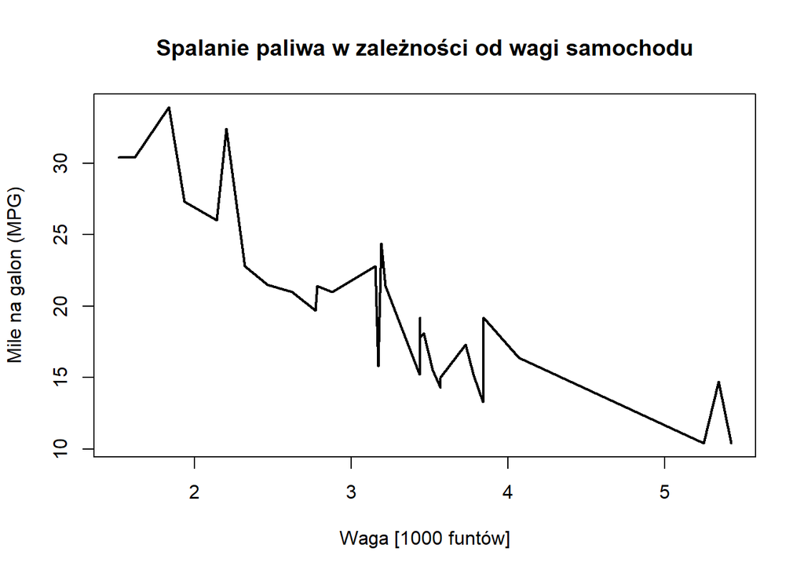

```r
# dane muszą być posortowane
sorted = mtcars[order(mtcars$wt), ]

plot(sorted$wt, sorted$mpg,
     type = "l",
     main = "Spalanie paliwa w zależności od wagi samochodu",
     xlab = "Waga [1000 funtów]",
     ylab = "Mile na galon (MPG)",
     lwd = 2)
```

## Wykres słupkowy

Wykres słupkowy służy do wizualnego przedstawiania danych kategorycznych za pomocą prostokątnych słupków. Wysokość lub długość słupków jest proporcjonalna do wartości, które reprezentują. Do wykresów słupkowych stosowana jest funkcja `barplot()` zamiast `plot()`.

```r
# zlicz wystąpienia dla każdego cylindra (grupy)
cyl_counts = table(mtcars$cyl)
cyl_counts
```

```
 4  6  8
11  7 14
```

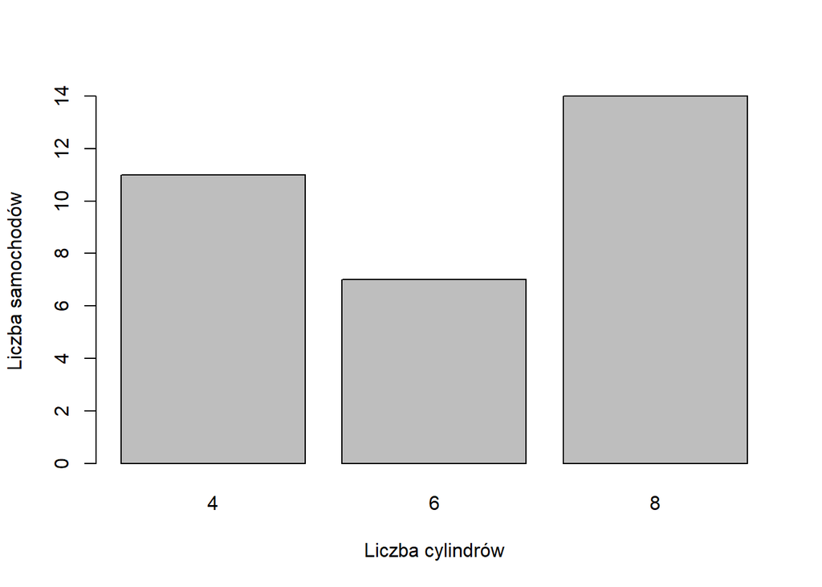

```r
barplot(cyl_counts, xlab = "Liczba cylindrów", ylab = "Liczba samochodów")
```

## Histogram

Histogram służy do przedstawienia rozkładu danych liczbowych w postaci słupków. Grupuje dane w przedziały (interwały) i pokazuje częstość wystąpień obserwacji mieszczących się w każdym z przedziałów. Kształt histogramu dostarcza istotnych informacji o rozkładzie danych (np. czy jest skośny czy symetryczny). Histogram można stworzyć używając funkcji `hist()`.

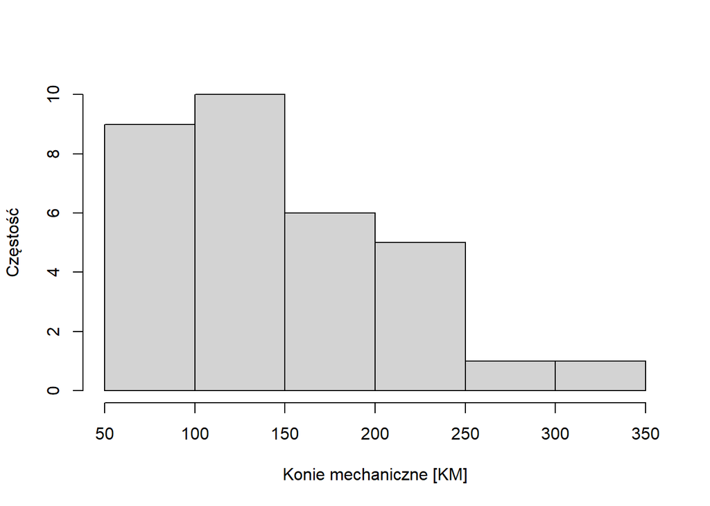

```r
hist(mtcars$hp, xlab = "Konie mechaniczne [KM]", ylab = "Częstość", main = NULL)
```

# Ustawienia wykresów

Wykresy można dostosować według własnego uznania, dodając lub modyfikując różne elementy za pomocą odpowiednich argumentów funkcji `plot()`.

## Kolor

Kolory punktów, linii, słupków i innych elementów można zmieniać używając argumentu `col`, natomiast argument `border` zmienia kolor obwódki. R obsługuje angielskie nazwy kolorów (np. `red`, `blue`), a także szesnastkowe kody kolorów (np. `#FF0000`; czerwony). Można również skorzystać z wbudowanych palet kolorów, takich jak `rainbow()`, `heat.colors()` czy `topo.colors()`. Pełna lista kolorów dostępna jest [tutaj](https://r-charts.com/colors/).

## Kształt i rozmiar punktów

Argument `pch` określa kształt punktów na wykresach punktowych, a argument `cex` odpowiada za ich rozmiar. Listę z kształtami punktów znajdziesz [tutaj](https://www.sthda.com/english/wiki/r-plot-pch-symbols-the-different-point-shapes-available-in-r).

## Typ i szerokość linii

W przypadku wykresów liniowych można dostosować typ oraz szerokość linii za pomocą argumentów `lty` oraz `lwd`. Typ linii (`lty`) można określić za pomocą tekstu (`"blank"`, `"solid"`, `"dashed"`, `"dotted"`, `"dotdash"`, `"longdash"`, `"twodash"`) lub liczby (0, 1, 2, 3, 4, 5, 6).

## Etykiety

Etykiety można edytować za pomocą argumentów takich jak `xlab` (opis osi X), `ylab` (opis osi Y) oraz `main` (tytuł wykresu).

## Dodawanie warstw

Do istniejącego wykresu można dodawać kolejne warstwy punktowe, liniowe lub poligonowe używając funkcji `points()`, `lines()`, `rect()` oraz `polygon()`.

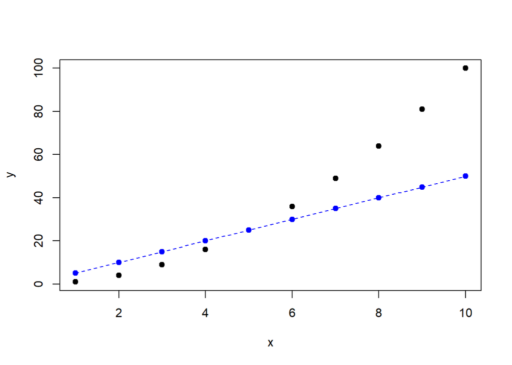

```r
plot(x, y, col = "black", pch = 19)
points(x, x*5, col = "blue", pch = 19)
lines(x, x*5, col = "blue", lty = 2)
```

## Linie pomocnicze

Funkcja `abline()` umożliwia dodanie linii w określonych lokalizacjach. W zależności od zdefiniowanych wartości argumentów, linia może być horyzontalna (argument `h`), wertykalna (argument `v`) lub może przedstawiać trend (argumenty `a` – wyraz wolny oraz `b` – współczynnik kierunkowy prostej).

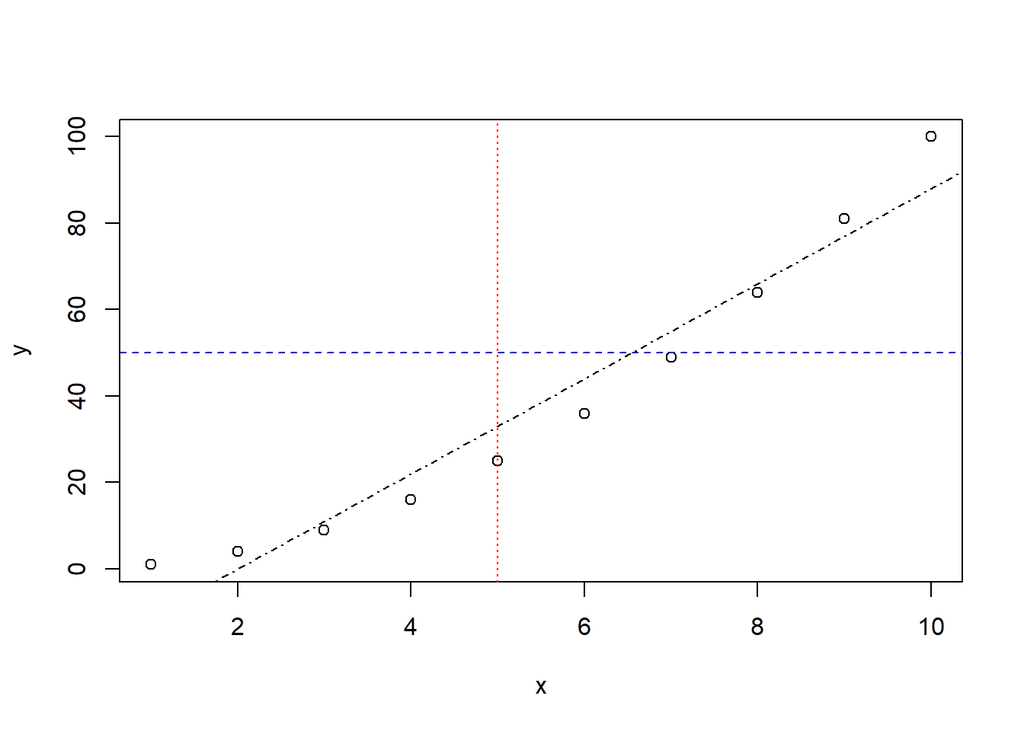

```r
plot(x, y)
# linia horyzontalna
abline(h = 50, col = "blue", lty = 2)
# linia wertykalna
abline(v = 5, col = "red", lty = 3)
# linia trendu
abline(a = -22, b = 11, col = "black", lty = 4)
```

## Tekst

Funkcja `text()` dodaje etykiety tekstowe do punktów lub określonych lokalizacji na wykresie. Wymagane jest określenie pozycji tekstu używając dwóch współrzędnych oraz podanie wektora tekstowego. Argumenty `pos` oraz `offset` pozwalają na przesunięcie tekstu względem punktów.

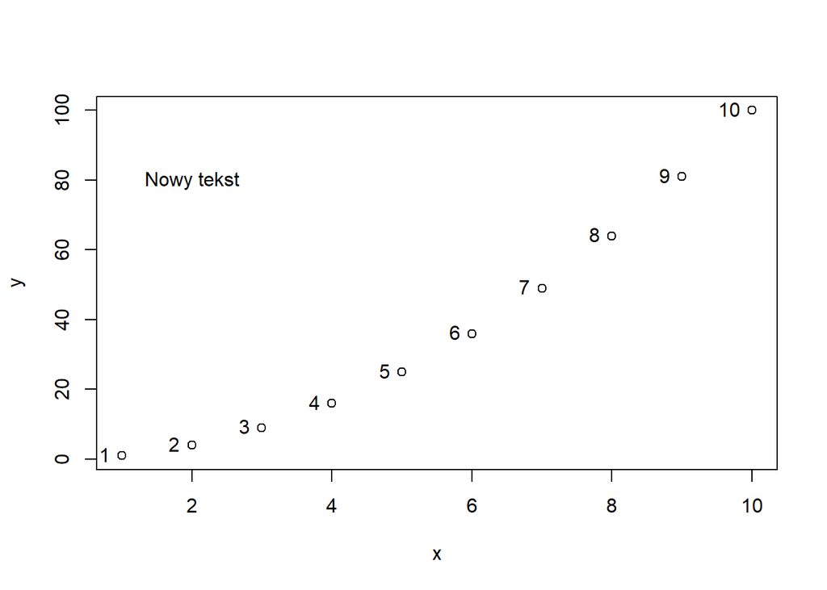

```r
plot(x, y)
text(x, y, labels = 1:10, pos = 2)
text(2, 80, labels = "Nowy tekst")
```

## Legenda

Legenda jest nieodzownym elementem interpretacji wykresów reprezentujących grupy lub serie danych. Do jej wygenerowania służy funkcja `legend()`, w której należy określić położenie, nazwy i kolory grup oraz tytuł.

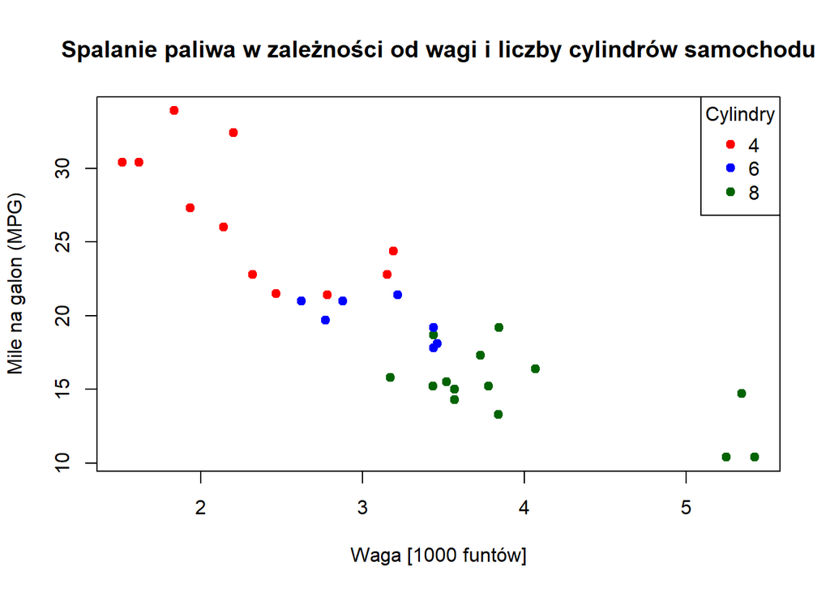

```r
# zamiana liczby cylindrów na kategorie
cyl_factor = as.factor(mtcars$cyl)
# zdefiniowanie kolorów
colors = c("red", "blue", "darkgreen")

plot(mtcars$wt, mtcars$mpg,
     main = "Spalanie paliwa w zależności od wagi i liczby cylindrów samochodu",
     xlab = "Waga [1000 funtów]",
     ylab = "Mile na galon (MPG)",
     pch = 19,
     # przypisanie kolorów do odpowiednich kategorii
     col = colors[cyl_factor])

legend("topright",
       legend = levels(cyl_factor),
       col = colors,
       pch = 19,
       title = "Cylindry")
```

## Wykresy wielopanelowe

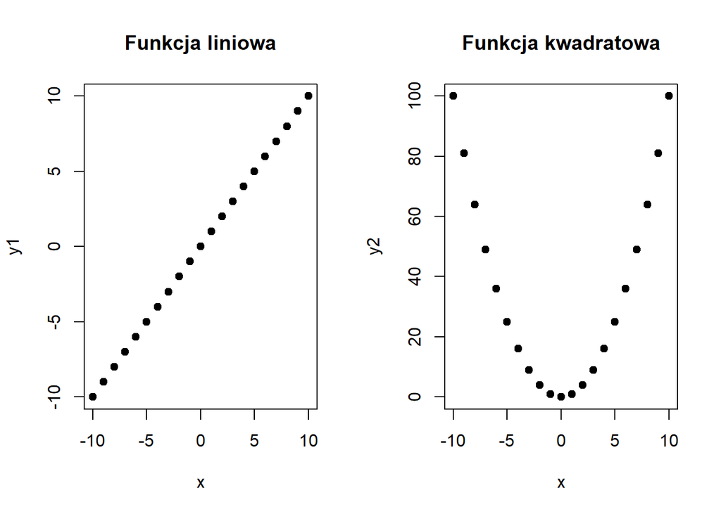

```r
x = -10:10
y1 = x
y2 = x^2

# panel składający się z dwóch kolumn
par(mfrow = c(1, 2))

plot(x, y1, main = "Funkcja liniowa", pch = 19)
plot(x, y2, main = "Funkcja kwadratowa", pch = 19)
```

```r
# reset do pojedynczego panelu
par(mfrow = c(1, 1))
```

# Zapisywanie wykresów

Stworzone wykresy można zapisać do plików w różnych formatach, np. `png`, `pdf` czy `jpeg`. Preferowane są formaty kompresji bezstratnej.

```r
# zapisanie ryciny w formacie png
png("wykres.png", width = 400, height = 300)
plot(x, y2, main = "Funkcja kwadratowa", pch = 19)
dev.off()
```

Zawsze należy użyć funkcji `dev.off()` po wygenerowaniu i zapisaniu wykresu do pliku.

# Zadania

1. Stwórz wykres liniowy z zaznaczonymi punktami. Zakres wartości zmiennej $X$ jest od -10 do 10, natomiast zmienna Y zawiera wartości bezwzględne zmiennej $X$.
2. Stwórz ponownie powyższy wykres, ale składający się z dwóch krzywych $Y$. Pierwsza krzywa $Y_1$ zawiera wartości z przedziału od -10 do 10 (kolor czarny), natomiast druga krzywa $Y_2$ zawiera wartości bezwzględne (kolor zielony).
3. Do powyższego wykresu dodaj horyzontalne oraz wertykalne linie pomocnicze o interwale 1. Linie powinny być przerywane, a ich kolor szary z ustawioną przezroczystością (`#BEBEBE4D`).
4. Stwórz wykres rozrzutu wykorzystując dane ze zbioru `iris` oraz zmienne `Sepal.Length` i `Sepal.Width`. Jako kolor uwzględnij gatunek irysów (zmienna `Species`) oraz dodaj legendę do wykresu.
5. Stwórz wykres słupkowy przedstawiający liczebność gatunków irysów. Każdy słupek oznacz innym kolorem z palety kolorów `rainbow`.
6. Na podstawie zmiennych `wt` oraz `mpg` ze zbioru `mtcars` stwórz wykres rozrzutu, następnie samodzielnie wyznacz linię trendu i dodaj ją do wykresu. Jaka jest wartość współczynnika kierunkowego prostej, a jaka wyrazu wolnego?
7. Stwórz histogram zmiennej `wt`. Ustaw odpowiednie etykiety osi. Wybierz również kolor słupków oraz obwódki. Jaki jest wniosek z interpretacji tego histogramu?